# Preliminary Assessment of the Dataset

John Ramírez, JR Engineering Company

2024-04-17

## Exploración Inicial de Datos

### Preliminares

```r
knitr::opts_chunk$set(echo = TRUE)
library(tidyverse)
data <- read.csv("./data/murders.csv")
```

### Visualización Inicial

Se muestra las primeras filas del conjunto de datos con head(data) y la estructura del conjunto de datos con str(data). Esto permite una inspección inicial de los datos.

```r
head(data)
```

```
##        state abb region population total
## 1    Alabama  AL  South    4779736   135
## 2     Alaska  AK   West     710231    19
## 3    Arizona  AZ   West    6392017   232
## 4   Arkansas  AR  South    2915918    93
## 5 California  CA   West   37253956  1257
## 6   Colorado  CO   West    5029196    65
```

```r
str(data)
```

```
## 'data.frame':    51 obs. of  5 variables:
##  $ state     : chr  "Alabama" "Alaska" "Arizona" "Arkansas" ...
##  $ abb       : chr  "AL" "AK" "AZ" "AR" ...
##  $ region    : chr  "South" "West" "West" "South" ...
##  $ population: int  4779736 710231 6392017 2915918 37253956 5029196 3574097 897934 601723 19687653 ...
##  $ total     : int  135 19 232 93 1257 65 97 38 99 669 ...
```

### Resumen Estadístico

Se proporciona un resumen estadístico de las variables numéricas en el conjunto de datos utilizando la función summary().

```r
summary(data)
```

```
##     state               abb               region            population
##  Length:51          Length:51          Length:51          Min.   :  563626
##  Class :character   Class :character   Class :character   1st Qu.: 1696962
##  Mode  :character   Mode  :character   Mode  :character   Median : 4339367
##                                                           Mean   : 6075769
##                                                           3rd Qu.: 6636084
##                                                           Max.   :37253956
##      total
##  Min.   :   2.0
##  1st Qu.:  24.5
##  Median :  97.0
##  Mean   : 184.4
##  3rd Qu.: 268.0
##  Max.   :1257.0
```

### Visualización de Variables Numéricas

Se crea histogramas y diagramas de caja para las variables “total” (número total de homicidios) y “population” (población). Los histogramas muestran la distribución de los datos, mientras que los diagramas de caja muestran la dispersión y los valores atípicos.

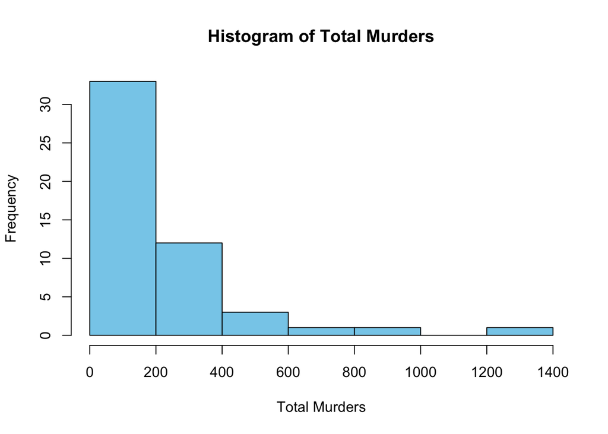

```r
#### Histogramas: Histograms provide a visual representation of the distribution of a numerical variable. They display the frequency of data points falling within certain intervals.

hist(data$total, main = "Histogram of Total Murders", xlab = "Total Murders", ylab = "Frequency", col = "skyblue")
```

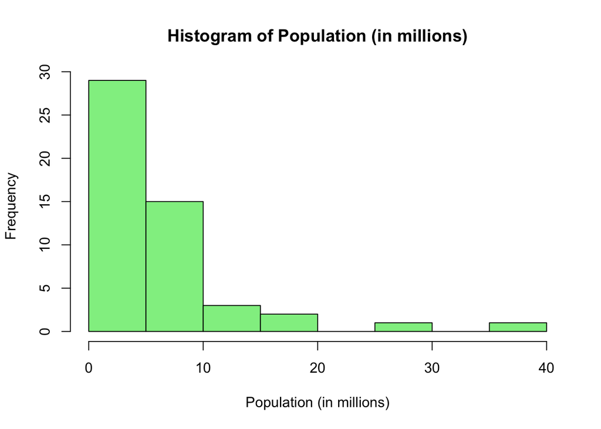

```r
hist(data$population / 10^6, main = "Histogram of Population (in millions)", xlab = "Population (in millions)", ylab = "Frequency", col = "lightgreen")
```

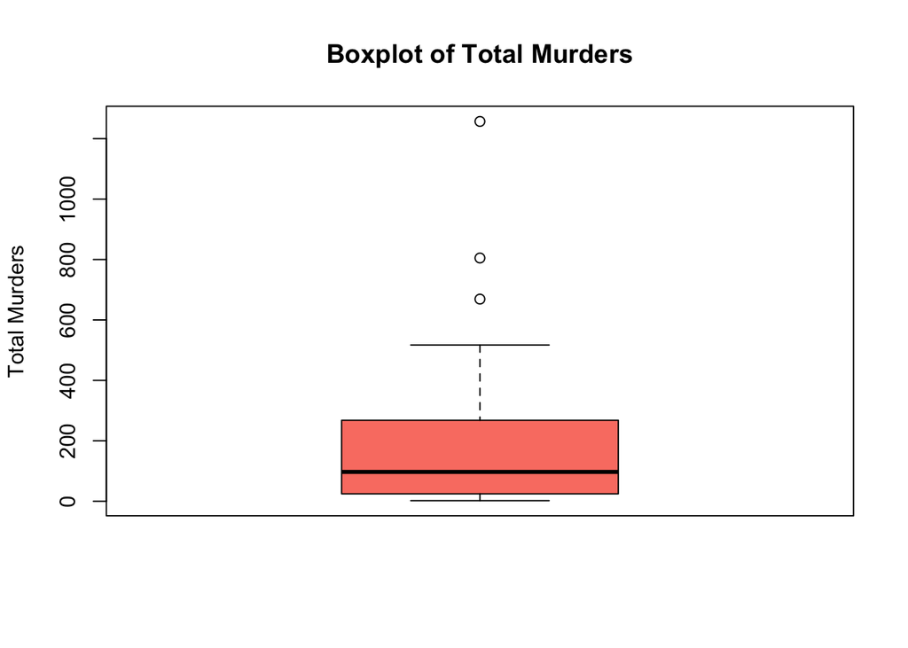

```r
#### Boxplots: The boxplots provide a visual summary of the distribution of the data. They display the median, quartiles, and potential outliers.

boxplot(data$total, main = "Boxplot of Total Murders", ylab = "Total Murders", col = "salmon")
```

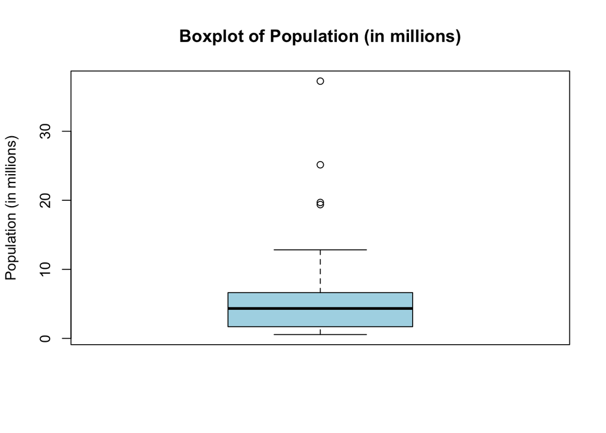

```r
boxplot(data$population / 10^6, main = "Boxplot of Population (in millions)", ylab = "Population (in millions)", col = "lightblue")
```

### Visualización de Relaciones

Se crea un gráfico de dispersión para explorar la relación entre “total” (número total de homicidios) y “population” (población). Se divide la población por 10^5 para escalar los valores a un rango más manejable.

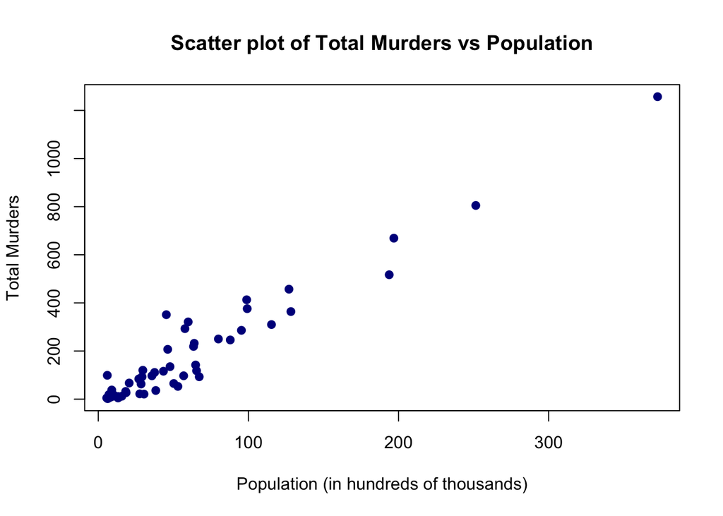

```r
plot(data$population/10^5, data$total, xlab = "Population (in hundreds of thousands)",
     ylab = "Total Murders",
     main = "Scatter plot of Total Murders vs Population",
     col = "darkblue",
     pch = 19)
```

### Tabla de Contingencia

Se crea una tabla de contingencia que muestra la frecuencia de combinaciones entre las variables “abb” (abreviaturas de estados) y “region” (región geográfica).

```r
table (data$abb, data$region)
```

```
##
##      North Central Northeast South West
##   AK             0         0     0    1
##   AL             0         0     1    0
##   AR             0         0     1    0
##   AZ             0         0     0    1
##   CA             0         0     0    1
##   CO             0         0     0    1
##   CT             0         1     0    0
##   DC             0         0     1    0
##   DE             0         0     1    0
##   FL             0         0     1    0
##   GA             0         0     1    0
##   HI             0         0     0    1
##   IA             1         0     0    0
##   ID             0         0     0    1
##   IL             1         0     0    0
##   IN             1         0     0    0
##   KS             1         0     0    0
##   KY             0         0     1    0
##   LA             0         0     1    0
##   MA             0         1     0    0
##   MD             0         0     1    0
##   ME             0         1     0    0
##   MI             1         0     0    0
##   MN             1         0     0    0
##   MO             1         0     0    0
##   MS             0         0     1    0
##   MT             0         0     0    1
##   NC             0         0     1    0
##   ND             1         0     0    0
##   NE             1         0     0    0
##   NH             0         1     0    0
##   NJ             0         1     0    0
##   NM             0         0     0    1
##   NV             0         0     0    1
##   NY             0         1     0    0
##   OH             1         0     0    0
##   OK             0         0     1    0
##   OR             0         0     0    1
##   PA             0         1     0    0
##   RI             0         1     0    0
##   SC             0         0     1    0
##   SD             1         0     0    0
##   TN             0         0     1    0
##   TX             0         0     1    0
##   UT             0         0     0    1
##   VA             0         0     1    0
##   VT             0         1     0    0
##   WA             0         0     0    1
##   WI             1         0     0    0
##   WV             0         0     1    0
##   WY             0         0     0    1
```

### Visualización con ggplot2

Luego, se crea un gráfico de dispersión con ggplot(), donde los puntos representan cada estado y la tasa de homicidios se muestra en el eje y. Se aplican algunas personalizaciones de estilo, como rotar las etiquetas del eje x y voltear los ejes y colocar leyendas para cada eje y un titulo para la gráfica.

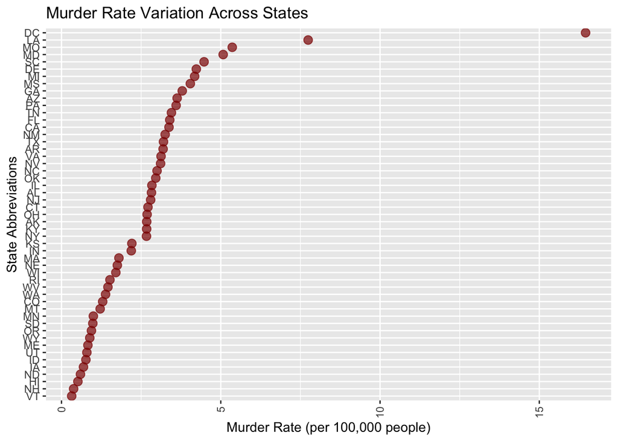

```r
data <- data %>% mutate(region = factor (region), rate = total / population * 10^5) %>% mutate(abb = reorder(abb, rate))

ggplot(data, aes (x=abb, y=rate )) + geom_point(color = "darkred", size = 3, alpha = 0.7) +
  theme(axis.text.x = element_text(angle = 90, vjust = 0.5, hjust = 1)) +
  coord_flip() +
  labs(x = "State Abbreviations",
       y = "Murder Rate (per 100,000 people)",
       title = "Murder Rate Variation Across States")
```

### Referencias

Dataset: “https://raw.githubusercontent.com/rafalab/dslabs/master/inst/extdata/murders.csv”